# COVID-19 Healthy Diet

```r
if (!require("tidyverse")) install.packages('tidyverse')
library("tidyverse")
library("shiny")
library("shinydashboard")
library("janitor")
library("naniar")
```

```r
library(tidyverse)
library(here)
library(janitor)
```

# Preliminary Analysis

```r
food_data<-read.csv("food and covid data/Food_Supply_Quantity_kg_Data_general_notation.csv")
food_data
```

```
##                                Country Alcoholic.Beverages Animal.fats
## 1                          Afghanistan              0.0014      0.1973
## 2                              Albania              1.6719      0.1357
## 3                              Algeria              0.2711      0.0282
## 4                               Angola              5.8087      0.0560
## 5                  Antigua and Barbuda              3.5764      0.0087
## 6                            Argentina              4.2672      0.2234
## 7                              Armenia              0.4014      0.1833
## 8                            Australia              5.5436      0.3143
## 9                              Austria              7.0215      0.8555
## 10                          Azerbaijan              3.5969      0.2544
## 11                             Bahamas              2.0175      0.0062
## 12                          Bangladesh              0.0031      0.0156
## 13                            Barbados              3.5650      0.2212
## 14                             Belarus              3.7563      0.3353
```

[output cut: 1182 more lines]

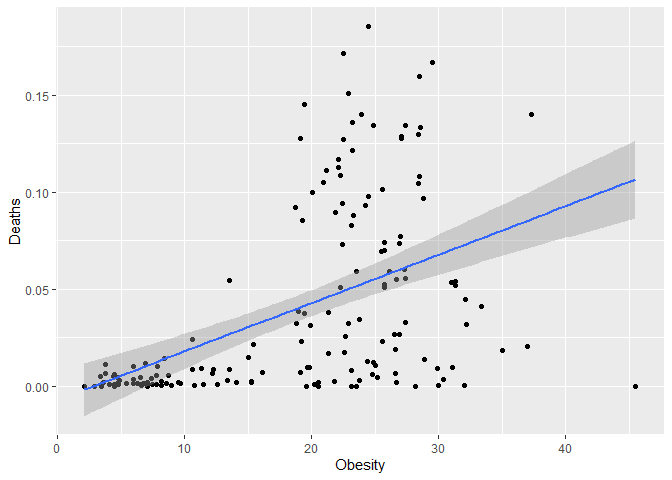

```r
food_data %>%
  group_by(Country) %>%
  ggplot(aes(Obesity,Deaths))+geom_point()+geom_smooth(method = lm)
```

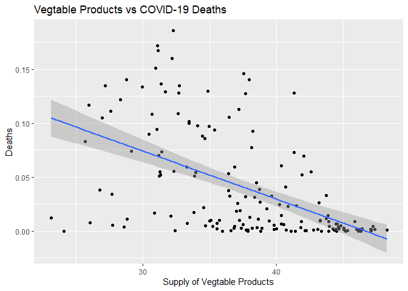

```r
food_data %>%
  group_by(Country) %>%
  ggplot(aes(Vegetal.Products,Deaths))+geom_point()+geom_smooth(method = lm) +
      labs(title = "Vegtable Products vs COVID-19 Deaths",x="Supply of Vegtable Products", y="Deaths")
```

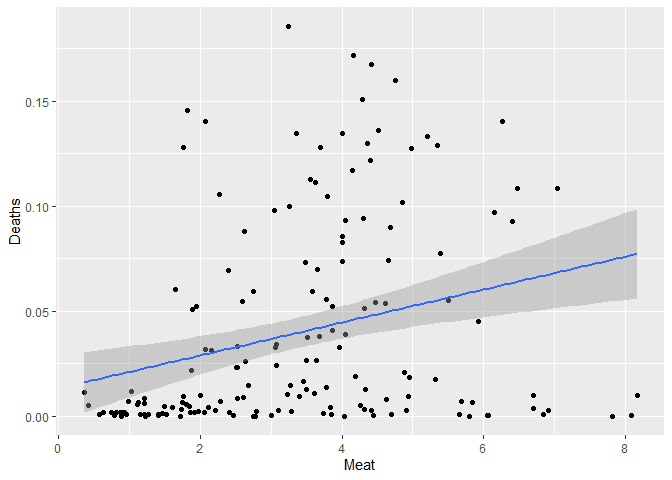

```r
food_data %>%
  group_by(Country) %>%
  ggplot(aes(Meat,Deaths))+geom_point()+geom_smooth(method = lm)
```

```r
food_data %>%
  select(Alcoholic.Beverages, Country) %>%
  arrange(desc(Alcoholic.Beverages))
```

```
##     Alcoholic.Beverages                            Country
## 1               15.3706                       Burkina Faso
## 2                9.8498                            Czechia
## 3                8.0858                         Luxembourg
## 4                7.8024                        Saint Lucia
## 5                7.5703                            Ireland
## 6                7.0834                           Bulgaria
## 7                7.0215                            Austria
## 8                6.8201                             Poland
## 9                6.7714                            Germany
## 10               6.7533                            Hungary
## 11               6.6254                             Panama
## 12               6.2658                       South Africa
## 13               6.2239                           Eswatini
## 14               6.1949                            Estonia
```

[output cut: 156 more lines]

# A Closer Look at Obesity

```r
#install.packages("ggpubr")
library(ggpubr)
```

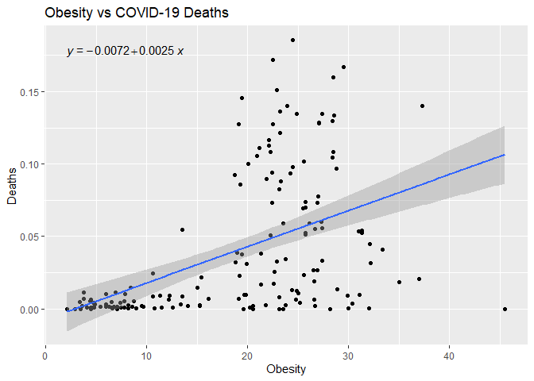

```r
food_data %>%
  group_by(Country) %>%
  ggplot(aes(Obesity,Deaths))+
  geom_point()+
  geom_smooth(method = lm, formula = y ~ x)+
  labs(title = "Obesity vs COVID-19 Deaths",
       x="Obesity",
       y="Deaths")+
  stat_regline_equation()
```

```r
food_data %>%
  select(Obesity,Country) %>%
  arrange(desc(Obesity))
```

```
##     Obesity                            Country
## 1      45.6                           Kiribati
## 2      45.5                              Samoa
## 3      37.3           United States of America
## 4      37.0                             Kuwait
## 5      35.0                       Saudi Arabia
## 6      33.4                             Jordan
## 7      32.2                             Turkey
## 8      32.1                            Bahamas
## 9      32.0                        New Zealand
## 10     31.3                             Canada
## 11     31.3                            Lebanon
## 12     31.1                              Egypt
## 13     31.0                              Malta
## 14     30.4                          Australia
```

[output cut: 156 more lines]

```r
island_food_data<- food_data %>%
  filter(Country== "Samoa"|
           Country=="United Kingdom"|
           Country=="Fiji" |
           Country=="Japan"|
           Country=="Australia"|
           Country=="New Zealand"|
           Country=="Kiribati"|
           Country=="Iceland"|
           Country=="Philippines") %>%
   mutate(Island= TRUE)
island_food_data
```

```
##          Country Alcoholic.Beverages Animal.fats Animal.Products
## 1      Australia              5.5436      0.3143         21.4175
## 2           Fiji              1.8598      0.2922          7.8511
## 3        Iceland              4.7545      0.9461         23.9700
## 4          Japan              4.0440      0.0751         15.3194
## 5       Kiribati              0.2970      0.0486          8.8958
## 6    New Zealand              5.2220      0.7446         17.5777
## 7    Philippines              1.9716      0.3074          6.7108
## 8          Samoa              1.4236      0.2262         11.1630
## 9 United Kingdom              5.2632      0.2754         18.8798
##   Aquatic.Products..Other Cereals...Excluding.Beer   Eggs Fish..Seafood
## 1                  0.0033                   5.4979 0.4428        1.4264
## 2                  0.0021                  10.1440 0.2682        2.3832
## 3                  0.0025                   4.1196 0.5557        4.6117
## 4                  0.1088                  12.1692 1.6960        3.9283
```

[output cut: 55 more lines]

```r
non_island_food_data<- food_data %>%
   filter( Country!="Australia",
           Country!="Samoa",
           Country!="United Kingdom",
           Country!="New Zealand",
           Country!="Kiribati",
           Country!="Iceland",
           Country!="Philippines",
           Country!="Fiji",
           Country!="Japan" ) %>%
  mutate(Island= FALSE)
non_island_food_data
```

```
##                                Country Alcoholic.Beverages Animal.fats
## 1                          Afghanistan              0.0014      0.1973
## 2                              Albania              1.6719      0.1357
## 3                              Algeria              0.2711      0.0282
## 4                               Angola              5.8087      0.0560
## 5                  Antigua and Barbuda              3.5764      0.0087
## 6                            Argentina              4.2672      0.2234
## 7                              Armenia              0.4014      0.1833
## 8                              Austria              7.0215      0.8555
## 9                           Azerbaijan              3.5969      0.2544
## 10                             Bahamas              2.0175      0.0062
## 11                          Bangladesh              0.0031      0.0156
## 12                            Barbados              3.5650      0.2212
## 13                             Belarus              3.7563      0.3353
## 14                             Belgium              5.3730      0.8559
```

[output cut: 1119 more lines]

```r
food_data %>%
  filter(Obesity>37) %>%
  select(Country, Confirmed, Deaths, Recovered)
```

```
##                    Country Confirmed   Deaths Recovered
## 1                 Kiribati        NA       NA        NA
## 2                    Samoa  0.001000 0.000000     0.001
## 3 United States of America  8.159922 0.140103     0.000
```

```r
island_food_complete <- rbind(non_island_food_data,
                              island_food_data)
```

```r
island_food_complete %>%
  select(Country, Undernourished) %>%
  arrange(desc(Undernourished))
```

```
##                                Country Undernourished
## 1                             Cameroon            9.9
## 2                                 Peru            9.7
## 3                   Dominican Republic            9.5
## 4                              Vietnam            9.3
## 5                          El Salvador              9
## 6                            Sri Lanka              9
## 7                      Solomon Islands            8.9
## 8                                Nepal            8.7
## 9                                China            8.5
## 10                            Suriname            8.5
## 11                           Indonesia            8.3
## 12                              Guyana            8.1
## 13                             Jamaica              8
## 14                             Ecuador            7.9
```

[output cut: 156 more lines]

## Obesity vs COVID-19 Deaths by Land Type

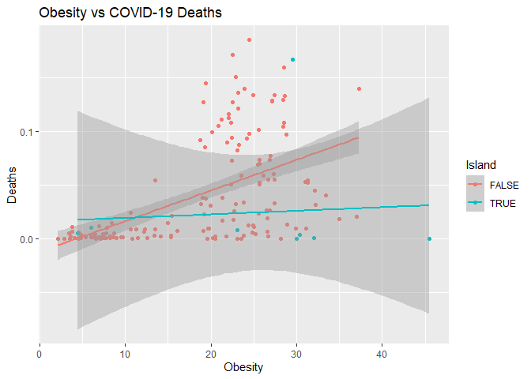

```r
island_food_complete %>%
  ggplot(aes(Obesity,Deaths,color=Island))+
  geom_point()+
  geom_smooth(method = lm)+
  labs(title = "Obesity vs COVID-19 Deaths",
       x="Obesity",
       y="Deaths")
```

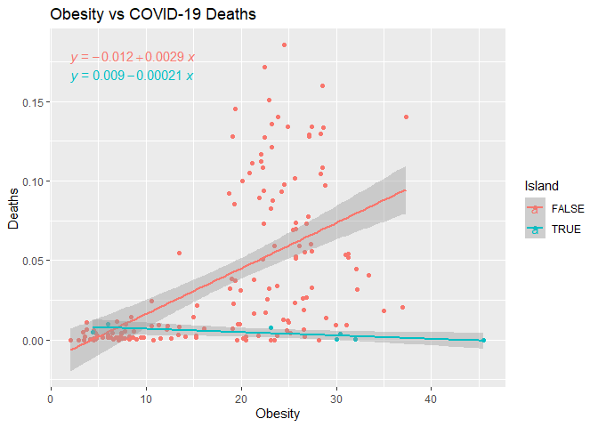

```r
island_food_complete %>%
  filter(Country!= "United Kingdom") %>%
  ggplot(aes(Obesity,Deaths,color=Island))+
  geom_point()+
  geom_smooth(method = lm)+
  labs(title = "Obesity vs COVID-19 Deaths"
      ,x="Obesity",
      y="Deaths")+
  stat_regline_equation()
```

## What’s Going on With the Islands

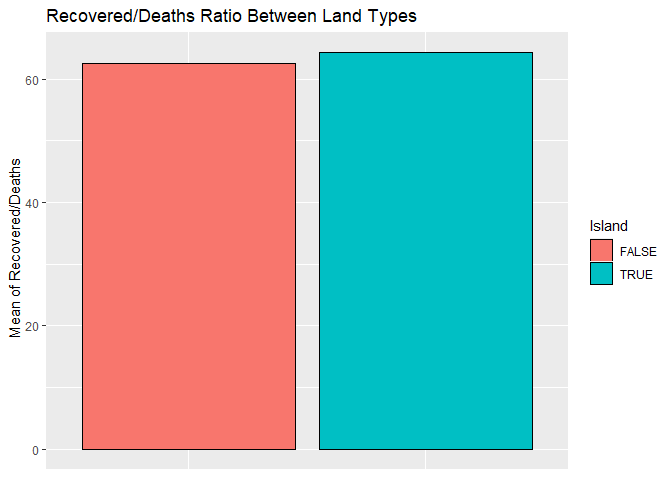

```r
island_food_complete %>%
  mutate(recovery_death_ratio=Recovered/Deaths) %>%
  group_by(Island) %>%
  filter(recovery_death_ratio!= Inf) %>%
  summarise(mean_reco_death_ratio=mean(recovery_death_ratio,na.rm=T)) %>%
  ggplot(aes(Island,mean_reco_death_ratio, fill= Island))+
  geom_col(color = "black")+
  labs(title = "Recovered/Deaths Ratio Between Land Types",
       x=NULL,
       y=" Mean of Recovered/Deaths")+
  theme(axis.text.x = element_blank(),
        axis.ticks.x = element_blank())
```

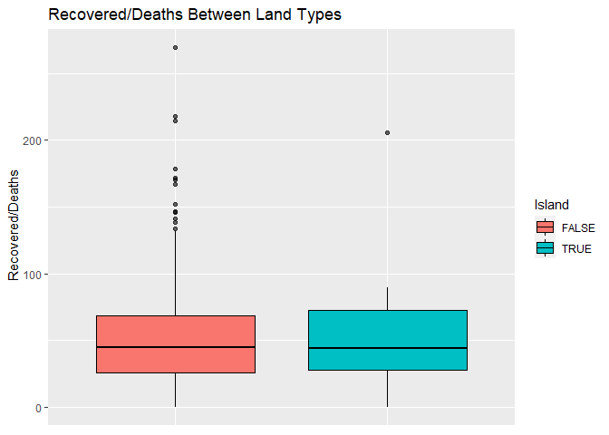

```r
island_food_complete %>%
  mutate(recovery_death_ratio=Recovered/Deaths) %>%
  filter(recovery_death_ratio!= Inf,
         recovery_death_ratio < 300) %>%
  ggplot(aes(Island, recovery_death_ratio,
             fill=Island))+
  geom_boxplot(outlier.alpha = 0.6,color = "black")+
  labs(title = "Recovered/Deaths Between Land Types",
       x=NULL,
       y=" Recovered/Deaths")+
  theme(axis.text.x = element_blank(),
        axis.ticks.x = element_blank())
```

# A Closer Look at Nourishment ## Cleaning the Data

```r
well_nourished_countries<-food_data %>%
  filter(Undernourished== "<2.5") %>%
  cbind(2.5) %>%
  mutate(Undernourished_numeric= mean(2.5)) %>%
  select(!"2.5")
```

```r
food_experiment<- food_data %>%
  filter(Undernourished != "<2.5")
```

```r
  food_experiment<-food_experiment %>%
  mutate(Undernourished_numeric=as.numeric(as.character(food_experiment$Undernourished)))
```

```r
nourishment_complete <- rbind(food_experiment, well_nourished_countries)
nourishment_complete
```

```
##                                Country Alcoholic.Beverages Animal.fats
## 1                          Afghanistan              0.0014      0.1973
## 2                              Albania              1.6719      0.1357
## 3                              Algeria              0.2711      0.0282
## 4                               Angola              5.8087      0.0560
## 5                            Argentina              4.2672      0.2234
## 6                              Armenia              0.4014      0.1833
## 7                           Bangladesh              0.0031      0.0156
## 8                             Barbados              3.5650      0.2212
## 9                               Belize              3.3803      0.0832
## 10                               Benin              5.9019      0.0132
## 11                             Bolivia              2.8956      0.0889
## 12                            Botswana              4.2717      0.3402
## 13                            Bulgaria              7.0834      0.2488
## 14                        Burkina Faso             15.3706      0.0231
```

[output cut: 1297 more lines]

```r
is.numeric(nourishment_complete$Undernourished_numeric)
```

```
## [1] TRUE
```

```r
nourishment_complete <- nourishment_complete %>%
             mutate(nourishment_catagory= case_when(Undernourished_numeric <=2.5 ~ "low undernourishment",
                                              Undernourished_numeric > 2.5 & Undernourished_numeric <= 15 ~ "medium undernourishment",
                                              Undernourished_numeric > 15 ~ "high undernourishment"))
nourishment_complete
```

```
##                                Country Alcoholic.Beverages Animal.fats
## 1                          Afghanistan              0.0014      0.1973
## 2                              Albania              1.6719      0.1357
## 3                              Algeria              0.2711      0.0282
## 4                               Angola              5.8087      0.0560
## 5                            Argentina              4.2672      0.2234
## 6                              Armenia              0.4014      0.1833
## 7                           Bangladesh              0.0031      0.0156
## 8                             Barbados              3.5650      0.2212
## 9                               Belize              3.3803      0.0832
## 10                               Benin              5.9019      0.0132
## 11                             Bolivia              2.8956      0.0889
## 12                            Botswana              4.2717      0.3402
## 13                            Bulgaria              7.0834      0.2488
## 14                        Burkina Faso             15.3706      0.0231
```

[output cut: 1297 more lines]

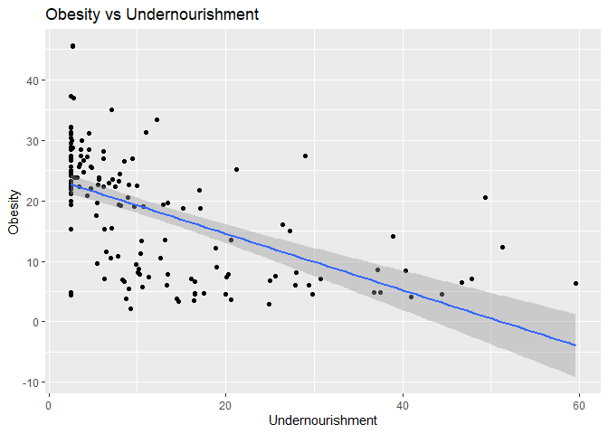

```r
nourishment_complete %>%
  ggplot(aes(Undernourished_numeric, Obesity))+
  geom_point()+geom_smooth(method = lm)+
  labs(title = "Obesity vs Undernourishment",
       x="Undernourishment",
       y="Obesity")
```

```r
nourishment_complete
```

```
##                                Country Alcoholic.Beverages Animal.fats
## 1                          Afghanistan              0.0014      0.1973
## 2                              Albania              1.6719      0.1357
## 3                              Algeria              0.2711      0.0282
## 4                               Angola              5.8087      0.0560
## 5                            Argentina              4.2672      0.2234
## 6                              Armenia              0.4014      0.1833
## 7                           Bangladesh              0.0031      0.0156
## 8                             Barbados              3.5650      0.2212
## 9                               Belize              3.3803      0.0832
## 10                               Benin              5.9019      0.0132
## 11                             Bolivia              2.8956      0.0889
## 12                            Botswana              4.2717      0.3402
## 13                            Bulgaria              7.0834      0.2488
## 14                        Burkina Faso             15.3706      0.0231
```

[output cut: 1297 more lines]

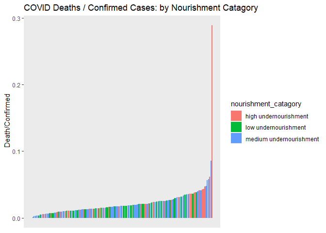

```r
nourishment_complete %>%
  mutate(confirmed_death_ratio=Deaths/Confirmed) %>%
  ggplot(aes(reorder(Country,confirmed_death_ratio),
             confirmed_death_ratio,
             fill=nourishment_catagory))+
  geom_col()+
  labs(title = "COVID Deaths / Confirmed Cases: by Nourishment Catagory",
       x=NULL,
       y=" Death/Confirmed")+
  theme(axis.text.x = element_blank(),
        axis.ticks.x = element_blank(),
        panel.grid.major = element_blank(),
        panel.grid.minor = element_blank())
```

```r
nourishment_complete %>%
  mutate(confirmed_death_ratio=Deaths/Confirmed) %>%
  filter(confirmed_death_ratio>0.1)
```

```
##   Country Alcoholic.Beverages Animal.fats Animal.Products
## 1   Yemen              0.0364      0.0446          5.7874
##   Aquatic.Products..Other Cereals...Excluding.Beer   Eggs Fish..Seafood
## 1                       0                  27.2077 0.2579         0.524
##   Fruits...Excluding.Wine   Meat Milk...Excluding.Butter Miscellaneous Offals
## 1                  5.1344 2.7871                  1.8911        0.2033 0.2827
##   Oilcrops Pulses Spices Starchy.Roots Stimulants Sugar...Sweeteners
## 1   0.0893 0.8645 0.0347        1.0794     0.2199             5.0468
##   Sugar.Crops Treenuts Vegetable.Oils Vegetables Vegetal.Products Obesity
## 1           0   0.0017         1.0811     3.2135          44.2126    14.1
##   Undernourished   Confirmed      Deaths   Recovered      Active Population
## 1           38.9 0.007131362 0.002061959 0.004787769 0.000281633   29826000
##   Unit..all.except.Population. Undernourished_numeric  nourishment_catagory
## 1                            %                   38.9 high undernourishment
##   confirmed_death_ratio
## 1             0.2891396
```

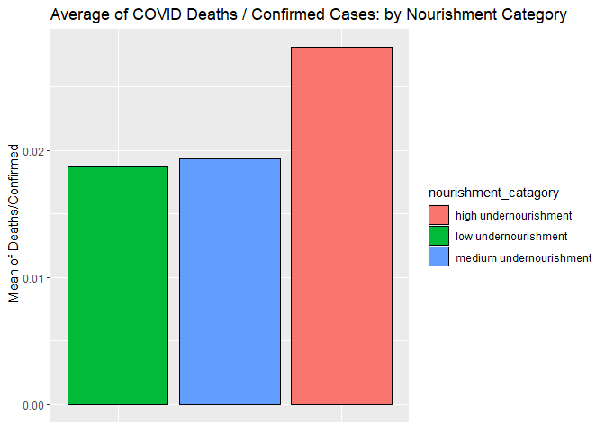

```r
nourishment_complete %>%
  mutate(confirmed_death_ratio=Deaths/Confirmed) %>%
  group_by(nourishment_catagory) %>%
  summarise(mean_confirmed_death_ratio= mean(confirmed_death_ratio,
                                             na.rm=T)) %>%
  ggplot(aes(reorder(nourishment_catagory,mean_confirmed_death_ratio),
             mean_confirmed_death_ratio, fill=nourishment_catagory))+
  geom_col(color = "black")+
  labs(title = "Average of COVID Deaths / Confirmed Cases: by Nourishment Category",
       x=NULL,
       y=" Mean of Deaths/Confirmed")+
  theme(axis.text.x = element_blank(),
        axis.ticks.x = element_blank())
```

# App Creation

```r
kg_gen_not<-read.csv("food and covid data/Food_Supply_Quantity_kg_Data_general_notation.csv")
```

```r
summary(kg_gen_not)
```

```
##    Country          Alcoholic.Beverages  Animal.fats      Animal.Products
##  Length:170         Min.   : 0.0000     Min.   :0.00100   Min.   : 1.739
##  Class :character   1st Qu.: 0.8956     1st Qu.:0.04022   1st Qu.: 7.237
##  Mode  :character   Median : 2.8662     Median :0.11685   Median :12.098
##                     Mean   : 3.0230     Mean   :0.22106   Mean   :12.182
##                     3rd Qu.: 4.7110     3rd Qu.:0.25390   3rd Qu.:16.444
##                     Max.   :15.3706     Max.   :1.35590   Max.   :26.887
##
##  Aquatic.Products..Other Cereals...Excluding.Beer      Eggs
##  Min.   :0.00000         Min.   : 3.401           Min.   :0.0239
##  1st Qu.:0.00000         1st Qu.: 7.227           1st Qu.:0.1876
##  Median :0.00000         Median :10.143           Median :0.4602
##  Mean   :0.01399         Mean   :11.800           Mean   :0.4706
##  3rd Qu.:0.00140         3rd Qu.:15.149           3rd Qu.:0.6442
##  Max.   :1.67940         Max.   :29.805           Max.   :1.6960
##
##  Fish..Seafood    Fruits...Excluding.Wine      Meat
##  Min.   :0.0342   Min.   : 0.6596         Min.   :0.356
##  1st Qu.:0.5571   1st Qu.: 3.5419         1st Qu.:1.891
##  Median :1.0292   Median : 5.0213         Median :3.425
##  Mean   :1.3872   Mean   : 5.6214         Mean   :3.376
##  3rd Qu.:1.8213   3rd Qu.: 6.8277         3rd Qu.:4.422
##  Max.   :8.7959   Max.   :19.3028         Max.   :8.170
##
##  Milk...Excluding.Butter Miscellaneous         Offals          Oilcrops
##  Min.   : 0.0963         Min.   :0.00000   Min.   :0.0000   Min.   : 0.0098
##  1st Qu.: 2.1723         1st Qu.:0.03232   1st Qu.:0.1051   1st Qu.: 0.1341
##  Median : 5.3369         Median :0.19685   Median :0.1668   Median : 0.3266
##  Mean   : 6.5198         Mean   :0.44312   Mean   :0.1934   Mean   : 0.8181
##  3rd Qu.:10.4071         3rd Qu.:0.58362   3rd Qu.:0.2286   3rd Qu.: 0.6917
##  Max.   :20.8378         Max.   :3.66340   Max.   :1.2256   Max.   :12.1763
##
##      Pulses           Spices        Starchy.Roots       Stimulants
##  Min.   :0.0000   Min.   :0.00000   Min.   : 0.6796   Min.   :0.00420
##  1st Qu.:0.1296   1st Qu.:0.01650   1st Qu.: 2.0238   1st Qu.:0.08332
##  Median :0.3008   Median :0.04255   Median : 3.1086   Median :0.15945
##  Mean   :0.5371   Mean   :0.09101   Mean   : 5.3354   Mean   :0.20195
##  3rd Qu.:0.7349   3rd Qu.:0.12315   3rd Qu.: 5.7459   3rd Qu.:0.26180
##  Max.   :3.4838   Max.   :0.66260   Max.   :27.7128   Max.   :1.28230
##
```

[output cut: 17 more lines]

```
##  Min.   : 0.000312   Min.   :0.000000   Min.   :0.00000   Min.   :0.00000
##  1st Qu.: 0.140976   1st Qu.:0.002013   1st Qu.:0.09911   1st Qu.:0.01203
##  Median : 1.011570   Median :0.011998   Median :0.47540   Median :0.08104
##  Mean   : 2.021972   Mean   :0.039370   Mean   :1.45236   Mean   :0.53516
##  3rd Qu.: 3.487069   3rd Qu.:0.069503   3rd Qu.:2.62287   3rd Qu.:0.35818
##  Max.   :10.408199   Max.   :0.185428   Max.   :9.03987   Max.   :8.01982
##  NA's   :6           NA's   :6          NA's   :6         NA's   :8
##    Population        Unit..all.except.Population.
##  Min.   :5.400e+04   Length:170
##  1st Qu.:2.816e+06   Class :character
##  Median :1.018e+07   Mode  :character
##  Mean   :4.452e+07
##  3rd Qu.:3.272e+07
##  Max.   :1.402e+09
##
```

```r
kg_gen_not%>%
  select(Country,Obesity)
```

```
##                                Country Obesity
## 1                          Afghanistan     4.5
## 2                              Albania    22.3
## 3                              Algeria    26.6
## 4                               Angola     6.8
## 5                  Antigua and Barbuda    19.1
## 6                            Argentina    28.5
## 7                              Armenia    20.9
## 8                            Australia    30.4
## 9                              Austria    21.9
## 10                          Azerbaijan    19.9
## 11                             Bahamas    32.1
## 12                          Bangladesh     3.4
## 13                            Barbados    24.8
## 14                             Belarus    26.6
```

[output cut: 156 more lines]

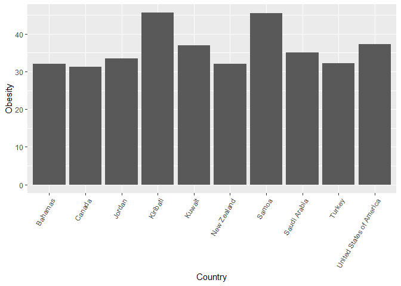

```r
kg_gen_not%>%
  select(Country,Obesity)%>%
  arrange(desc(Obesity))%>%
  head(10)%>%
  ggplot(aes(x=Country,y=Obesity))+
  geom_col()+
   theme(legend.position = "bottom",
        axis.text.x = element_text(angle = 60, hjust=1))
```

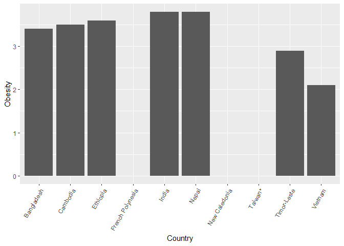

```r
kg_gen_not%>%
  select(Country,Obesity,Deaths)%>%
  arrange(desc(Obesity))%>%
  tail(10)%>%
  ggplot(aes(x=Country,y=Obesity))+
  geom_col()+
   theme(legend.position = "bottom",
        axis.text.x = element_text(angle = 60, hjust=1))
```

```r
kg_gen_not%>%
  select(Country,Obesity,Deaths)%>%
  filter(Obesity!="NA")%>%
  arrange(desc(Obesity))%>%
  tail(10)
```

```
##         Country Obesity       Deaths
## 158  Madagascar     4.5 0.0010147700
## 159       Japan     4.4 0.0050592620
## 160      Uganda     4.1 0.0007148950
## 161       India     3.8 0.0110703520
## 162       Nepal     3.8 0.0067842380
## 163    Ethiopia     3.6 0.0018665810
## 164    Cambodia     3.5 0.0000000000
## 165  Bangladesh     3.4 0.0048230660
## 166 Timor-Leste     2.9 0.0000000000
## 167     Vietnam     2.1 0.0000363791
```

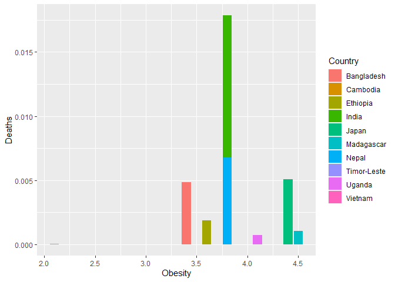

```r
kg_gen_not%>%
  select(Country,Obesity,Deaths)%>%
  filter(Obesity!="NA")%>%
  arrange(desc(Obesity))%>%
  tail(10)%>%
  ggplot(aes(x=Obesity,y=Deaths,fill=Country))+
  geom_col()
```

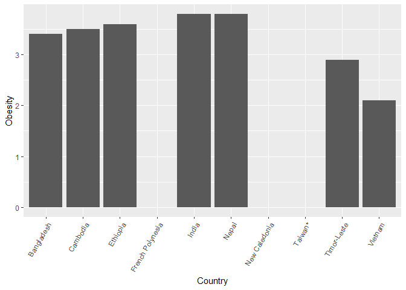

```r
kg_gen_not%>%
  select(Country,Obesity,Deaths)%>%
  arrange(desc(Obesity))%>%
  tail(10)%>%
  ggplot(aes(x=Country,y=Obesity))+
  geom_col()+
   theme(legend.position = "bottom",
        axis.text.x = element_text(angle = 60, hjust=1))
```

```r
kg_gen_not%>%
  select(Obesity,Country,Confirmed,Deaths,Recovered)%>%
  filter(Recovered!=0)%>%
  filter(Deaths!=0)%>%
  summarise(Country,recovery_to_death_ratio=Recovered/Deaths)%>%
  arrange(desc(recovery_to_death_ratio))%>%
  head(10)
```

```
##                 Country recovery_to_death_ratio
## 1              Mongolia                724.5000
## 2  United Arab Emirates                329.4103
## 3              Maldives                269.5555
## 4              Malaysia                218.1681
## 5              Thailand                214.4562
## 6               Iceland                205.4828
## 7             Sri Lanka                178.3305
## 8         Cote d'Ivoire                171.4383
## 9                Guinea                170.4761
## 10               Kuwait                167.1089
```

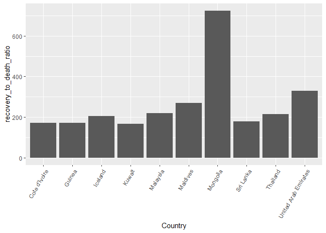

```r
kg_gen_not%>%
  select(Obesity,Country,Confirmed,Deaths,Recovered)%>%
  filter(Recovered!=0)%>%
  filter(Deaths!=0)%>%
  summarise(Country,recovery_to_death_ratio=Recovered/Deaths)%>%
  arrange(desc(recovery_to_death_ratio))%>%
  head(10)%>%
  ggplot(aes(x=Country,y=recovery_to_death_ratio))+
  geom_col()+
  theme(legend.position = "bottom",
        axis.text.x = element_text(angle = 60, hjust=1))
```

#observe the diets and and obesity rates of high recovery nations

```r
high_recovery_nations<-kg_gen_not%>%
  filter(Country=="Mongolia"|Country== "United Arab Emirates"|Country=="Maldives"|Country=="Malaysia"|Country=="Thailand"|Country=="Iceland"|Country=="Sri Lanka"|Country=="Cote d'Ivoire"|Country=="Guinea"|Country=="Kuwait")
```

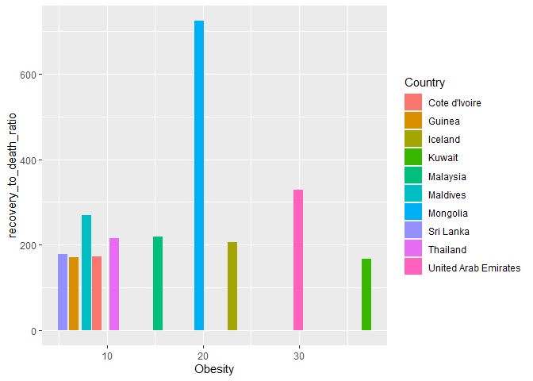

```r
high_recovery_nations%>%
  select(Obesity,Country,Confirmed,Deaths,Recovered)%>%
  filter(Recovered!=0)%>%
  filter(Deaths!=0)%>%
  summarise(Country,Obesity,recovery_to_death_ratio=Recovered/Deaths)%>%
  ggplot(aes(x=Obesity,y=recovery_to_death_ratio,fill=Country))+
  geom_col()
```

#so this is kinda weird, mongolia has high recovery and is moderate in obesity scale, maybe it has to do with the specifics of their diet #for now lets look at highest infection rate countries

```r
#high obesity
kg_gen_not%>%
  arrange(desc(Deaths))%>%
  summarise(Country,Confirmed,Recovered,Deaths,Obesity,recovery_to_death_ratio=Recovered/Deaths)%>%
  head(10)
```

```
##                     Country Confirmed  Recovered    Deaths Obesity
## 1                   Belgium  6.286322 0.00000000 0.1854277    24.5
## 2                  Slovenia  8.235901 7.31293390 0.1717546    22.5
## 3            United Kingdom  5.868483 0.01516081 0.1672201    29.5
## 4                   Czechia  9.612841 8.55532848 0.1598451    28.5
## 5                     Italy  4.353685 3.49452866 0.1509271    22.9
## 6    Bosnia and Herzegovina  3.762085 2.96031698 0.1455349    19.4
## 7           North Macedonia  4.548029 4.02572115 0.1401923    23.9
## 8  United States of America  8.159922 0.00000000 0.1401030    37.3
## 9                  Portugal  7.429605 5.84683569 0.1360702    23.2
## 10                 Bulgaria  3.227256 2.78895626 0.1344161    27.4
##    recovery_to_death_ratio
## 1               0.00000000
## 2              42.57779629
## 3               0.09066382
## 4              53.52262261
## 5              23.15375318
## 6              20.34094240
## 7              28.71570639
## 8               0.00000000
## 9              42.96925602
## 10             20.74868437
```

```r
high_obesity<-kg_gen_not%>%
  arrange(desc(Obesity))%>%
  summarise(Country,Confirmed,Recovered,Deaths,Obesity,Population,Recovery_to_death_ratio=Recovered/Deaths)%>%
  head(10)
```

#need to fix USA’s recovered column that looks like an error

```r
#low obesity
kg_gen_not%>%
  select(Country,Confirmed,Recovered,Deaths,Obesity,Population)%>%
  filter(Obesity!="NA")%>%
  arrange(desc(Obesity))%>%
  tail(10)
```

```
##         Country   Confirmed   Recovered       Deaths Obesity Population
## 158  Madagascar 0.068849085 0.065779495 0.0010147700     4.5   27691000
## 159       Japan 0.320820532 0.284769821 0.0050592620     4.4  125967000
## 160      Uganda 0.087057563 0.031370106 0.0007148950     4.1   45741000
## 161       India 0.773256410 0.751560674 0.0110703520     3.8 1400100000
## 162       Nepal 0.906140819 0.892825710 0.0067842380     3.8   29996000
## 163    Ethiopia 0.123092520 0.109237182 0.0018665810     3.6  114916000
## 164    Cambodia 0.003058657 0.002929599 0.0000000000     3.5   15497000
## 165  Bangladesh 0.316691106 0.284343586 0.0048230660     3.4  169809000
## 166 Timor-Leste 0.006069803 0.004628225 0.0000000000     2.9    1318000
## 167     Vietnam 0.002063217 0.001525845 0.0000363791     2.1   96209000
```

```r
low_obesity_1<-kg_gen_not%>%
  select(Country,Confirmed,Recovered,Deaths,Obesity,Population)%>%
  filter(Confirmed!="NA"& Obesity!="NA" & Deaths!=0)%>%
  arrange(desc(Obesity))%>%
  tail(10)%>%
  summarise(Country,Confirmed,Recovered,Deaths,Obesity,Population,Recovery_to_death_ratio=Recovered/Deaths)
```

```r
low_obesity_1
```

```
##         Country   Confirmed   Recovered       Deaths Obesity Population
## 1   Afghanistan 0.142134196 0.123373921 0.0061857790     4.5   38928000
## 2  Burkina Faso 0.053709994 0.048031383 0.0006410560     4.5   20903000
## 3    Madagascar 0.068849085 0.065779495 0.0010147700     4.5   27691000
## 4         Japan 0.320820532 0.284769821 0.0050592620     4.4  125967000
## 5        Uganda 0.087057563 0.031370106 0.0007148950     4.1   45741000
## 6         India 0.773256410 0.751560674 0.0110703520     3.8 1400100000
## 7         Nepal 0.906140819 0.892825710 0.0067842380     3.8   29996000
## 8      Ethiopia 0.123092520 0.109237182 0.0018665810     3.6  114916000
## 9    Bangladesh 0.316691106 0.284343586 0.0048230660     3.4  169809000
## 10      Vietnam 0.002063217 0.001525845 0.0000363791     2.1   96209000
##    Recovery_to_death_ratio
## 1                 19.94477
## 2                 74.92541
## 3                 64.82207
## 4                 56.28683
## 5                 43.88072
## 6                 67.88950
## 7                131.60295
## 8                 58.52260
## 9                 58.95494
## 10                41.94290
```

```r
high_obesity
```

```
##                     Country  Confirmed  Recovered      Deaths Obesity
## 1                  Kiribati         NA         NA          NA    45.6
## 2                     Samoa 0.00100000 0.00100000 0.000000000    45.5
## 3  United States of America 8.15992185 0.00000000 0.140103008    37.3
## 4                    Kuwait 3.62472820 3.43408655 0.020549989    37.0
## 5              Saudi Arabia 1.05579464 1.03089809 0.018255758    35.0
## 6                    Jordan 3.12627587 2.99175953 0.040912070    33.4
## 7                    Turkey 3.01513787 2.88105019 0.031867633    32.2
## 8                   Bahamas 2.10076336 1.73511450 0.044783715    32.1
## 9               New Zealand 0.04652095 0.04469621 0.000501303    32.0
## 10                   Canada 2.10996072 1.90984813 0.054202671    31.3
##    Population Recovery_to_death_ratio
## 1      125000                      NA
## 2      200000                     Inf
## 3   329878000                 0.00000
## 4     4691000               167.10892
## 5    35041000                56.46975
## 6    10679000                73.12657
## 7    83737000                90.40678
## 8      393000                38.74432
## 9     4987000                89.16007
## 10   38190000                35.23531
```

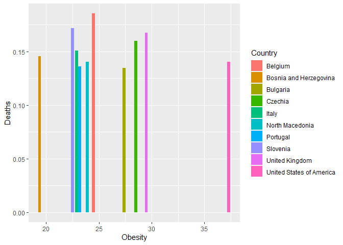

```r
kg_gen_not%>%
  arrange(desc(Deaths))%>%
  summarise(Country,Confirmed,Recovered,Deaths,Obesity)%>%
  head(10)%>%
    ggplot(aes(x=Obesity,y=Deaths,fill=Country))+
  geom_col()
```

```r
#comparing low vs high obesity relative to covid death rate by countries
high_and_low_obesity_recovery<-rbind(low_obesity_1,high_obesity)

high_and_low_obesity_recovery
```

```
##                     Country   Confirmed   Recovered       Deaths Obesity
## 1               Afghanistan 0.142134196 0.123373921 0.0061857790     4.5
## 2              Burkina Faso 0.053709994 0.048031383 0.0006410560     4.5
## 3                Madagascar 0.068849085 0.065779495 0.0010147700     4.5
## 4                     Japan 0.320820532 0.284769821 0.0050592620     4.4
## 5                    Uganda 0.087057563 0.031370106 0.0007148950     4.1
## 6                     India 0.773256410 0.751560674 0.0110703520     3.8
## 7                     Nepal 0.906140819 0.892825710 0.0067842380     3.8
## 8                  Ethiopia 0.123092520 0.109237182 0.0018665810     3.6
## 9                Bangladesh 0.316691106 0.284343586 0.0048230660     3.4
## 10                  Vietnam 0.002063217 0.001525845 0.0000363791     2.1
## 11                 Kiribati          NA          NA           NA    45.6
## 12                    Samoa 0.001000000 0.001000000 0.0000000000    45.5
## 13 United States of America 8.159921850 0.000000000 0.1401030080    37.3
## 14                   Kuwait 3.624728203 3.434086549 0.0205499890    37.0
```

[output cut: 27 more lines]

```r
names(high_and_low_obesity_recovery)
```

```
## [1] "Country"                 "Confirmed"
## [3] "Recovered"               "Deaths"
## [5] "Obesity"                 "Population"
## [7] "Recovery_to_death_ratio"
```

#USE THIS FOR APP COMPARISONS BETWEEN HIGH AND LOW OBESITY RATE COUNTRIES ON RECOVERY TO DEATH RATIO #this the comparison between high and low obesity with a recovery to death ratio

```r
library(shiny)

ui_1 <- dashboardPage(
  dashboardHeader(title = "Test"),
  dashboardSidebar(),
  dashboardBody(
    selectInput("x","Select X variable",choices = c("Population","Recovered","Obesity","Deaths",'Recovery_to_death_ratio=Recovered/Deaths'),
              selected = "Deaths"),
 selectInput("y","Select y variable",choices = c("Population","Recovered","Obesity","Deaths",'Recovery_to_death_ratio=Recovered/Deaths'),
              selected = "Deaths"),
 box(title = "Test", width = 10,
  plotOutput("plot",width = "1000px",height = "900px")

)
)
)

server_1 <- function(input, output) {
  output$plot<-renderPlot({
  ggplot(high_and_low_obesity_recovery,aes_string(x=input$x,y=input$y, color="Country")) + geom_point(size=10)+ theme_light(base_size = 18)#+theme(legend.position = "bottom",axis.text=element_text(angle = 60,hjust = 1))
    })
    #session$onSessionEnded(stopApp)
    }

shinyApp(ui_1,server_1)
```

#population vs number of cases pick out the ones with the highest

```r
names(kg_gen_not)
```

```
##  [1] "Country"                      "Alcoholic.Beverages"
##  [3] "Animal.fats"                  "Animal.Products"
##  [5] "Aquatic.Products..Other"      "Cereals...Excluding.Beer"
##  [7] "Eggs"                         "Fish..Seafood"
##  [9] "Fruits...Excluding.Wine"      "Meat"
## [11] "Milk...Excluding.Butter"      "Miscellaneous"
## [13] "Offals"                       "Oilcrops"
## [15] "Pulses"                       "Spices"
## [17] "Starchy.Roots"                "Stimulants"
## [19] "Sugar...Sweeteners"           "Sugar.Crops"
## [21] "Treenuts"                     "Vegetable.Oils"
## [23] "Vegetables"                   "Vegetal.Products"
## [25] "Obesity"                      "Undernourished"
## [27] "Confirmed"                    "Deaths"
## [29] "Recovered"                    "Active"
## [31] "Population"                   "Unit..all.except.Population."
```

“Country”,“Alcoholic.Beverages”,“Animal.fats”,“Animal.Products”,“Aquatic.Products..Other”,“Cereals…Excluding.Beer”,“Eggs”,“Fish..Seafood”, “Fruits…Excluding.Wine”,“Meat”,“Milk…Excluding.Butter”,“Miscellaneous”,“Offals”,“Oilcrops”,“Pulses”,“Spices”,“Starchy.Roots”,“Stimulants”,“Sugar…Sweeteners”,“Sugar.Crops” “Treenuts”,“Vegetable.Oils”,“Vegetables”,“Vegetal.Products”,“Obesity”,“Undernourished”,“Confirmed”,“Deaths”,“Recovered”,“Active”,“Population”,“Unit..all.except.Population.”

#use for app adding a ratio column, has not set to update variable in app yet

```r
kg_gen_not%>%
  summarise(Country,Alcoholic.Beverages,Animal.fats,Animal.Products,Aquatic.Products..Other,Cereals...Excluding.Beer,Eggs,Fish..Seafood,Fruits...Excluding.Wine,Meat,Milk...Excluding.Butter,Miscellaneous,Offals,Oilcrops,Pulses,Spices,Starchy.Roots,Stimulants,Sugar...Sweeteners,Sugar.Crops,Treenuts,Vegetable.Oils,Vegetables,Vegetal.Products,Obesity,Undernourished,Confirmed,Deaths,Recovered,Active,Population,Unit..all.except.Population.,Recovery_to_Death_Ratio=Recovered/Deaths)%>%
  filter(across(c(Country,Alcoholic.Beverages,Animal.fats,Animal.Products,Aquatic.Products..Other,Cereals...Excluding.Beer,Eggs,Fish..Seafood,Fruits...Excluding.Wine,Meat,Milk...Excluding.Butter,Miscellaneous,Offals,Oilcrops,Pulses,Spices,Starchy.Roots,Stimulants,Sugar...Sweeteners,Sugar.Crops,Treenuts,Vegetable.Oils,Vegetables,Vegetal.Products,Obesity,Undernourished,Confirmed,Deaths,Recovered,Active,Population,Unit..all.except.Population.,Recovery_to_Death_Ratio=Recovered/Deaths),~!is.na(.x)))
```

```
##                                Country Alcoholic.Beverages Animal.fats
## 1                          Afghanistan              0.0014      0.1973
## 2                              Albania              1.6719      0.1357
## 3                              Algeria              0.2711      0.0282
## 4                               Angola              5.8087      0.0560
## 5                            Argentina              4.2672      0.2234
## 6                              Armenia              0.4014      0.1833
## 7                            Australia              5.5436      0.3143
## 8                              Austria              7.0215      0.8555
## 9                           Azerbaijan              3.5969      0.2544
## 10                          Bangladesh              0.0031      0.0156
## 11                            Barbados              3.5650      0.2212
## 12                             Belarus              3.7563      0.3353
## 13                             Belgium              5.3730      0.8559
## 14                              Belize              3.3803      0.0832
```

[output cut: 1225 more lines]

```r
kg_gen_not<-kg_gen_not%>%
  summarise(Country,Alcoholic.Beverages,Animal.fats,Animal.Products,Aquatic.Products..Other,Cereals...Excluding.Beer,Eggs,Fish..Seafood,Fruits...Excluding.Wine,Meat,Milk...Excluding.Butter,Miscellaneous,Offals,Oilcrops,Pulses,Spices,Starchy.Roots,Stimulants,Sugar...Sweeteners,Sugar.Crops,Treenuts,Vegetable.Oils,Vegetables,Vegetal.Products,Obesity,Undernourished,Confirmed,Deaths,Recovered,Active,Population,Unit..all.except.Population.,Recovery_to_Death_Ratio=Recovered/Deaths)
```

#USE THIS FOR APP LARGE SCALE OVER VIEW #app for general overview #remove under nourished

```r
library(shiny)

ui_1 <- dashboardPage(
  dashboardHeader(title = "Diet Observations"),
  dashboardSidebar(),
  dashboardBody(
    selectInput("x","Select X variable",choices=c("Country","Alcoholic.Beverages","Animal.fats","Animal.Products","Aquatic.Products..Other","Cereals...Excluding.Beer","Eggs","Fish..Seafood","Fruits...Excluding.Wine","Meat","Milk...Excluding.Butter","Miscellaneous","Offals","Oilcrops","Pulses","Spices","Starchy.Roots","Stimulants","Sugar...Sweeteners","Sugar.Crops","Treenuts","Vegetable.Oils","Vegetables","Vegetal.Products","Obesity","Undernourished","Confirmed","Deaths","Recovered","Active","Population","Unit..all.except.Population.","Recovery_to_Death_Ratio"),
              selected = "Alcoholic.Beverages"),
 selectInput("y","Select y variable",choices = c("Country","Alcoholic.Beverages","Animal.fats","Animal.Products","Aquatic.Products..Other","Cereals...Excluding.Beer","Eggs","Fish..Seafood","Fruits...Excluding.Wine","Meat","Milk...Excluding.Butter","Miscellaneous","Offals","Oilcrops","Pulses","Spices","Starchy.Roots","Stimulants","Sugar...Sweeteners","Sugar.Crops","Treenuts","Vegetable.Oils","Vegetables","Vegetal.Products","Obesity","Undernourished","Confirmed","Deaths","Recovered","Active","Population","Unit..all.except.Population.","Recovery_to_Death_Ratio"),
              selected = "Deaths"),
 box(title = "Diet Compared to COVID-19 Deaths", width = 15,
  plotOutput("plot",width = "1000px",height = "900px")


)
)
)

server_1 <- function(input, output) {
  output$plot<-renderPlot({
  ggplot(kg_gen_not,aes_string(x=input$x,y=input$y)) + geom_point(size=4.5)+ theme_light(base_size = 18)+geom_smooth(method = lm)+theme(plot.title = element_text(hjust = 2))
    })
    #session$onSessionEnded(stopApp)
    }

shinyApp(ui_1,server_1)
```

```r
country_comparison<-kg_gen_not%>%
  filter(Country=="Vietnam"|Country=="United States of America"|Country=="New Zealand"|Country=="United Kingdom"|Country=="Italy"|Country=="Korea, South")%>%
  summarise(Country,Confirmed,Recovered,Deaths,Obesity,Population,Recovery_to_death_ratio=Recovered/Deaths)
```

#USE FOR APP THIS IS SMALL SCALE COMPARISON OF COUNTRIES

```r
library(shiny)

ui_1 <- dashboardPage(
  dashboardHeader(title = "Test"),
  dashboardSidebar(),
  dashboardBody(
    selectInput("x","Select X variable",choices=c("Country","Population","Recovered","Obesity","Deaths","Recovery_to_death_ratio"),
              selected = "Country"),
 selectInput("y","Select y variable",choices = c("Country","Population","Recovered","Obesity","Deaths", "Recovery_to_death_ratio"),
              selected = "Deaths"),
 box(title = "Test", width = 10,
  plotOutput("plot",width = "1000px",height = "900px")


)
)
)

server_1 <- function(input, output) {
  output$plot<-renderPlot({
  ggplot(country_comparison,aes_string(x=input$x,y=input$y,fill="Country")) + geom_col()+ theme_light(base_size = 18)+ geom_smooth(method = lm) +theme(legend.position = "bottom",axis.text=element_text(angle = 60,hjust = 1))
    })
    #session$onSessionEnded(stopApp)
    }

shinyApp(ui_1,server_1)
```

```r
library(shiny)

ui_1 <- dashboardPage(
  dashboardHeader(title = "Test"),
  dashboardSidebar(),
  dashboardBody(
    selectInput("x","Select X variable",choices=c("Country","Population","Recovered","Obesity","Deaths","Recovery_to_death_ratio"),
              selected = "Deaths"),
 selectInput("y","Select y variable",choices = c("Country","Population","Recovered","Obesity","Deaths", "Recovery_to_death_ratio"),
              selected = "Deaths"),
 box(title = "Test", width = 10,
  plotOutput("plot",width = "1000px",height = "900px")


)
)
)

server_1 <- function(input, output) {
  output$plot<-renderPlot({
  ggplot(kg_gen_not,aes_string(x=input$x,y=input$y)) + geom_point()+ theme_light(base_size = 18)+ geom_smooth(method = lm) +theme(legend.position = "bottom",axis.text=element_text(angle = 60,hjust = 1))
    })
   #session$onSessionEnded(stopApp)
    }


shinyApp(ui_1,server_1)
```